# ASSIGNMENT VISUALIZATION

Prahlad

13/07/2020

```r
library(dplyr)
```

```r
library(ggplot2)
```

Data Visualization Assignment

```r
c_churn<-read.csv('Customer_Churn.csv')
View(c_churn)
```

Problem Statement:

Sam has successfully completed the data manipulation phase. Now, he has to represent the data pictorially to get a better understanding. Sam will start off by making some bar plots by using the geom_bar() function from the ggplot2 package Questions on geom_bar():

1. Build a bar-plot for the ‘PhoneService’ column

```r
table(c_churn$PhoneService)
```

```
##
##   No  Yes
##  682 6361
```

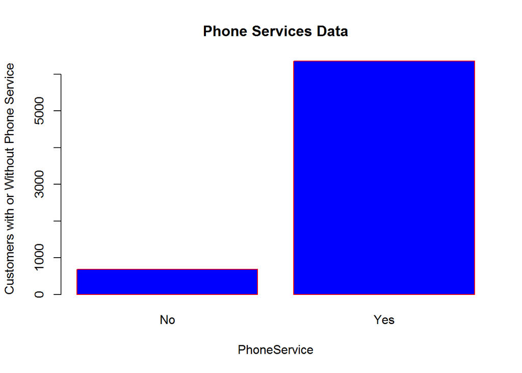

```r
barplot(table(c_churn$PhoneService), xlab= 'PhoneService', ylab='Customers with or Without Phone Service', main = 'Phone Services Data', col='blue', border='red')
```

Sam has successfully completed the data manipulation phase. Now, he has to represent the data pictorially to get a better understanding. Sam will start off by making some bar plots by using the geom_bar() function from the ggplot2 package Questions on geom_bar():

1. Build a bar-plot for the ‘PhoneService’ column

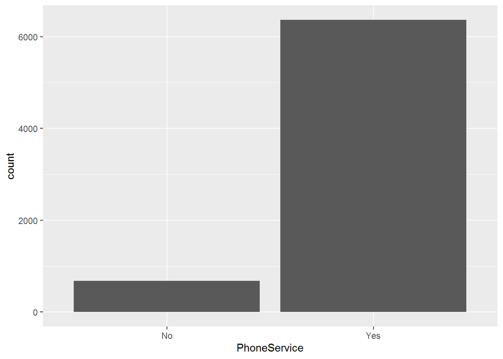

```r
ggplot(c_churn, aes(x=PhoneService))+geom_bar()
```

1. Assign the fill color to be ‘pink’

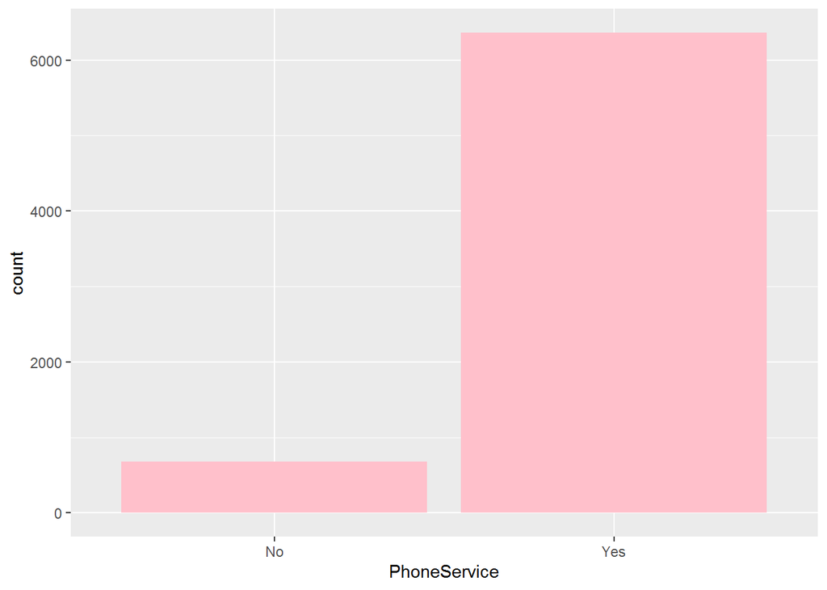

```r
ggplot(c_churn, aes(x=PhoneService))+geom_bar(fill='pink')
```

b. Assign the boundary color to be ‘peru’

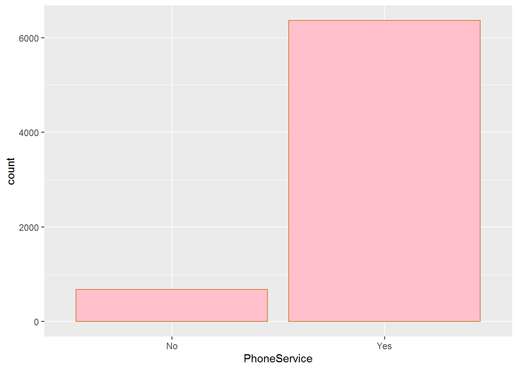

```r
ggplot(c_churn, aes(x=PhoneService))+geom_bar(fill='pink',col='peru')
```

2. Build a bar-plot for the ’InternetService’ column

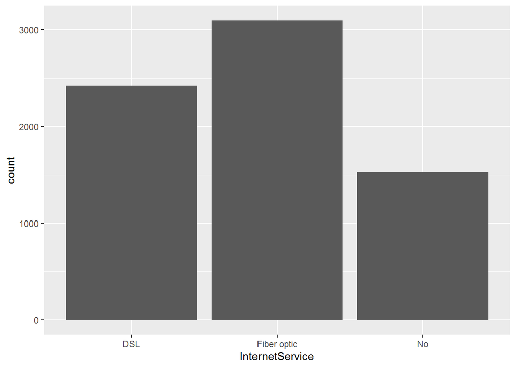

```r
ggplot(c_churn, aes(x=InternetService))+geom_bar()
```

1. Assign ‘InternetService’ to the fill aesthetic

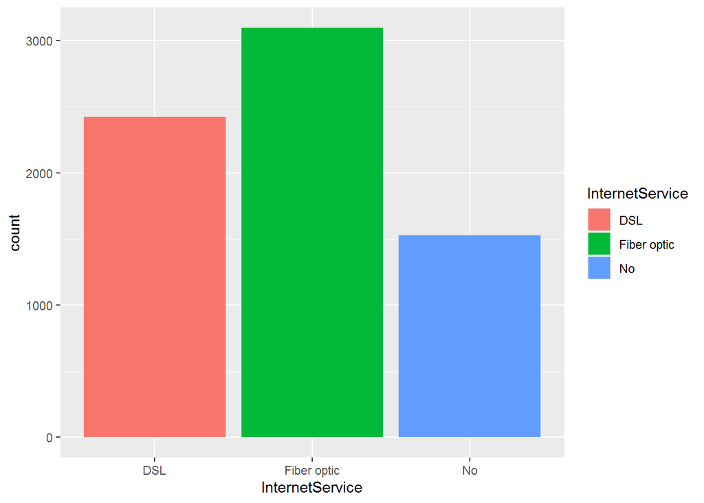

```r
ggplot(c_churn, aes(x=InternetService, fill=InternetService))+geom_bar()
```

2. Assign ‘Contract’ to the fill aesthetic

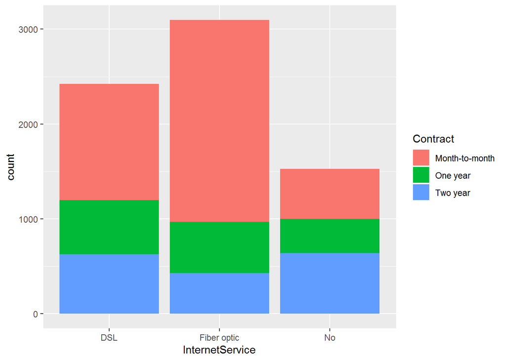

```r
ggplot(c_churn, aes(x=InternetService, fill=Contract))+geom_bar()
```

3. Change the position of bars to ‘identity’

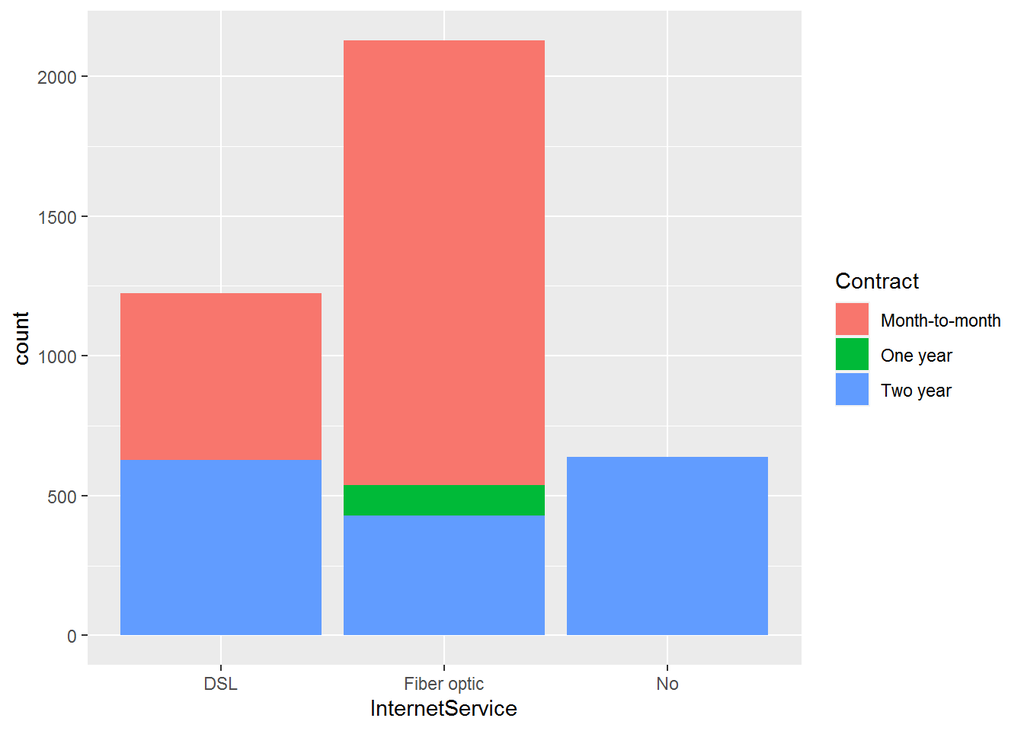

```r
ggplot(c_churn, aes(x=InternetService, fill=Contract))+geom_bar(position='identity')
```

3. Build a bar-plot for ‘TechSupport’ column

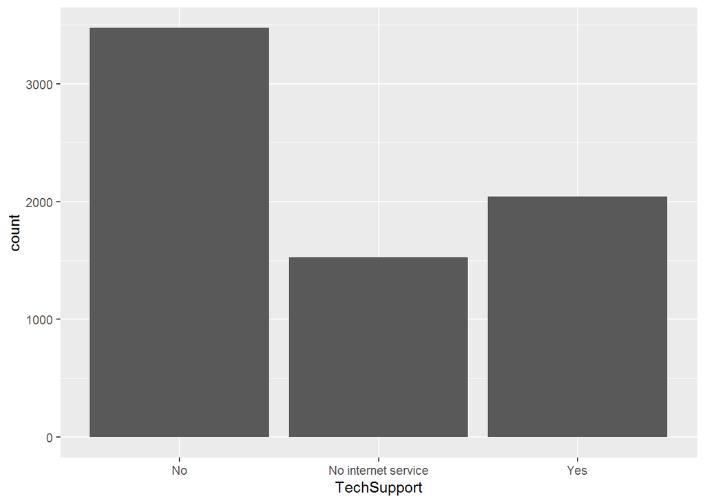

```r
ggplot(c_churn, aes(x=TechSupport))+geom_bar()
```

1. Assign ‘Churn’ to the fill aesthetic

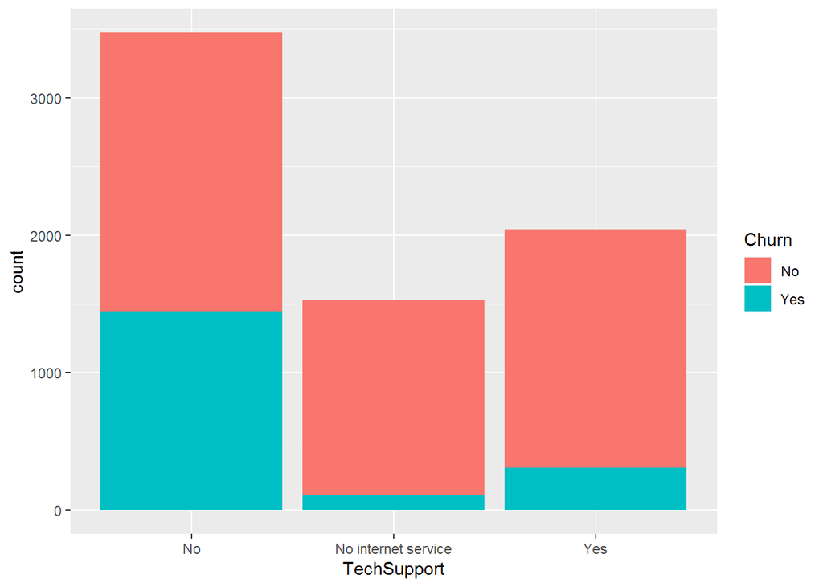

```r
ggplot(c_churn, aes(x=TechSupport, fill=Churn))+geom_bar()
```

Now, Sam will go ahead & make some histograms by using the geom_histogram() function Questions on geom_histogram():

1. Build a histogram for the ‘tenure’ column

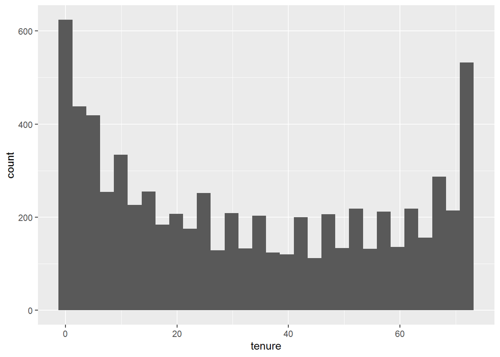

```r
ggplot(c_churn,aes(x=tenure))+geom_histogram()
```

a. Assign the fill color to be ‘mediumspringgreen’

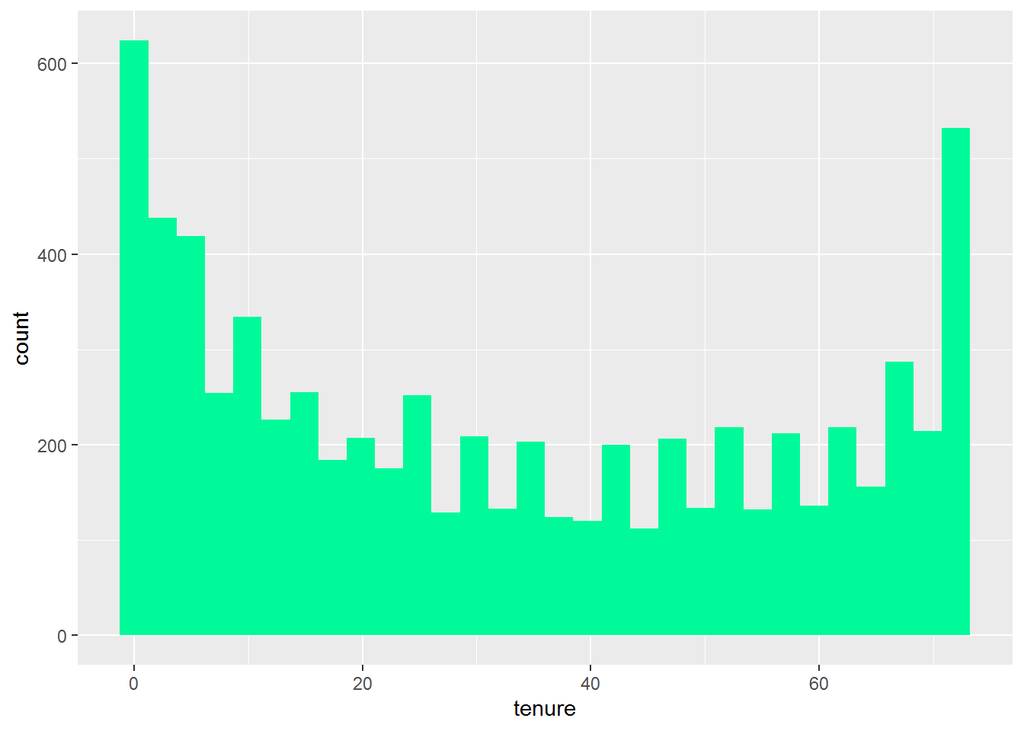

```r
ggplot(c_churn, aes(x=tenure))+geom_histogram(fill='mediumspringgreen')
```

2. Assign the boundary color to be ‘azure’

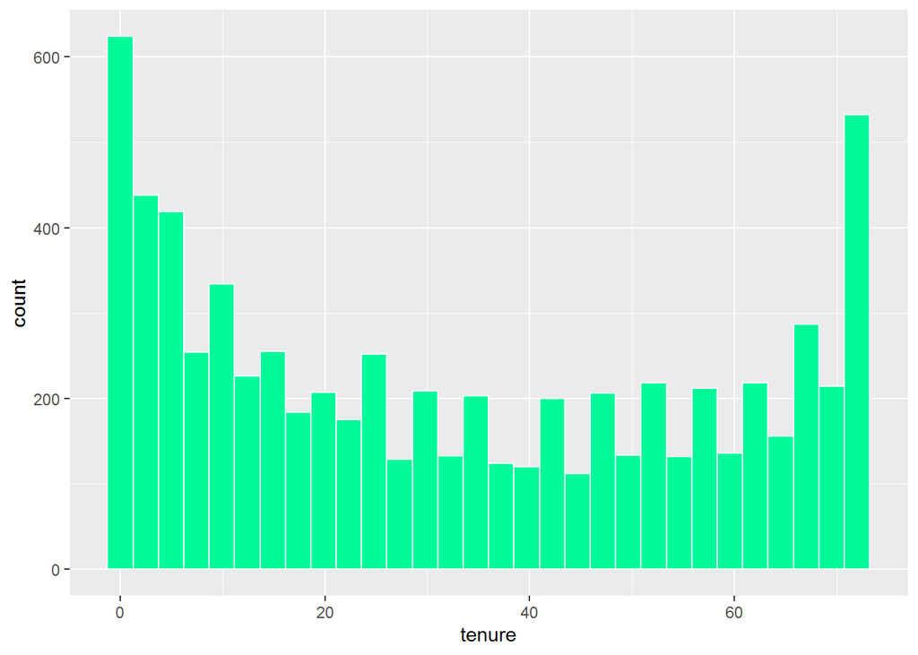

```r
ggplot(c_churn, aes(x=tenure))+geom_histogram(fill='mediumspringgreen', col='azure')
```

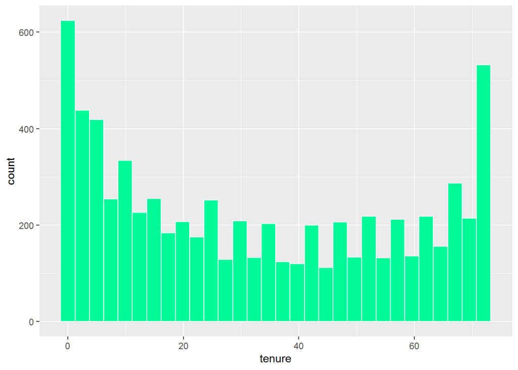

```r
ggplot(c_churn,  aes(x=tenure))+geom_histogram(fill='mediumspringgreen', col='azure',bins = 30)
```

2. Build histogram for the ‘MonthlyCharges’ column

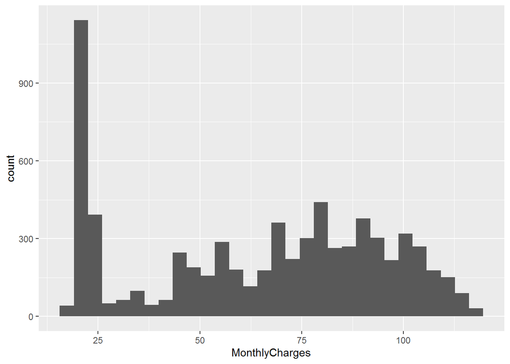

```r
ggplot(c_churn, aes(x=MonthlyCharges))+geom_histogram()
```

1. Assign ‘PaymentMethod’ to the fill aesthetic

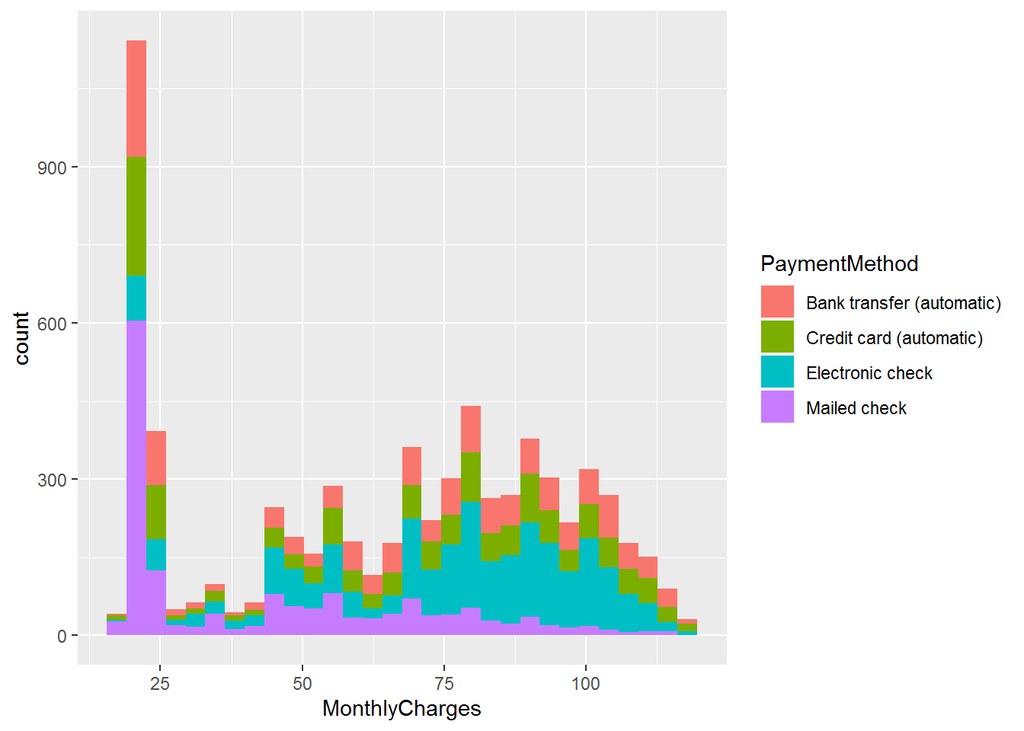

```r
ggplot(c_churn, aes(x=MonthlyCharges, fill=PaymentMethod))+geom_histogram()
```

2. Assign ‘OnlineBackup’ to the fill aesthetic

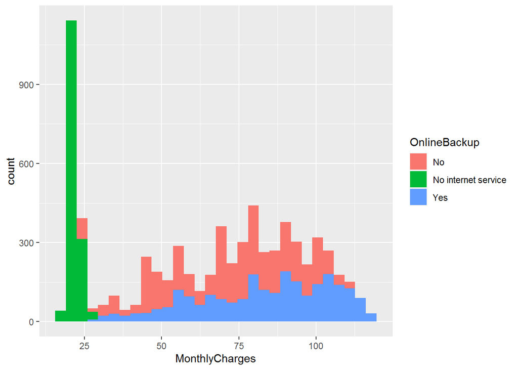

```r
ggplot(c_churn, aes(x=MonthlyCharges, fill=OnlineBackup))+geom_histogram()
```

3. Build histogram for the ‘TotalCharges’ column

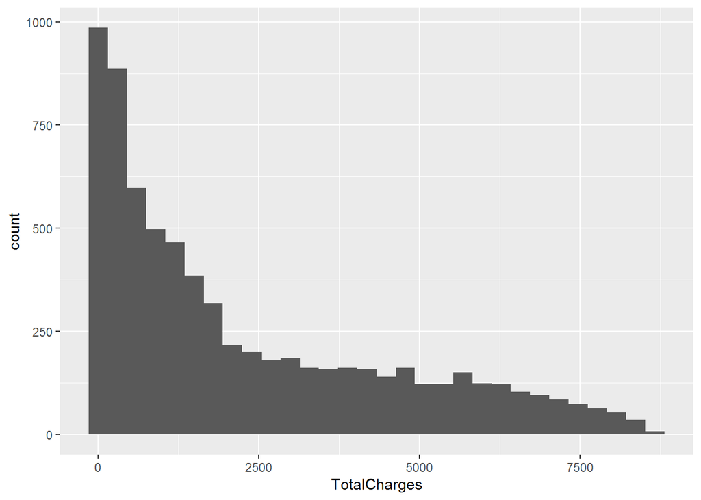

```r
ggplot(c_churn, aes(x=TotalCharges))+geom_histogram()
```

1. Assign ‘gender’ to the fill aesthetic

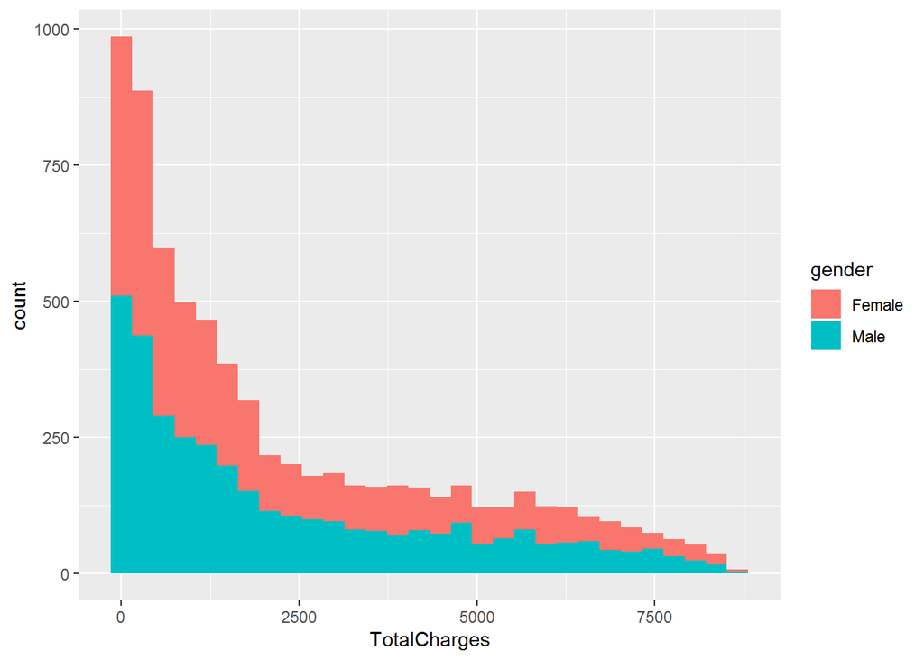

```r
ggplot(c_churn, aes(x=TotalCharges, fill=gender))+geom_histogram()
```

2. Assign ‘InternetService’ to the fill aesthetic

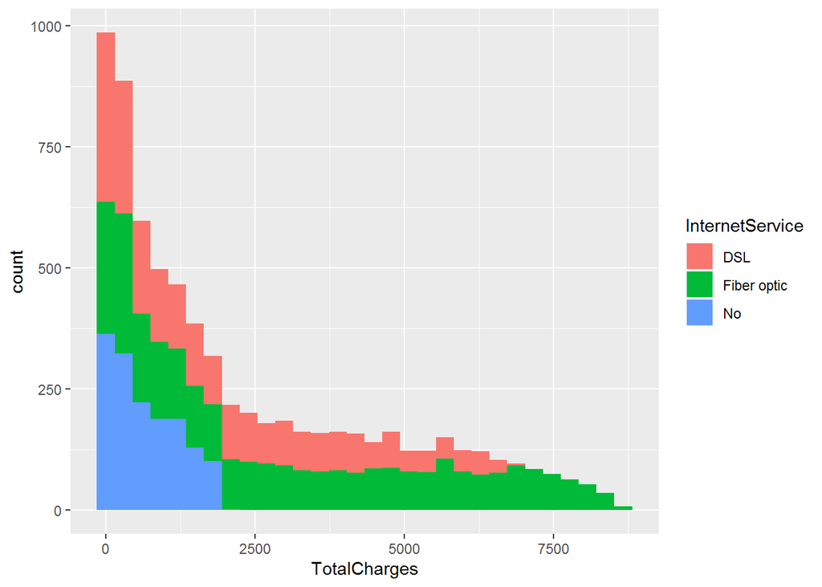

```r
ggplot(c_churn, aes(x=TotalCharges, fill=InternetService))+geom_histogram()
```

Now, Sam decides to make some scatter-plots on the data by using geom_point() function Questions on geom_point():

1. Build a scatter-plot between ‘TotalCharges’ & ‘tenure’. Map ‘TotalCharges’ to the y-axis & ‘tenure’ to the ‘x-axis’

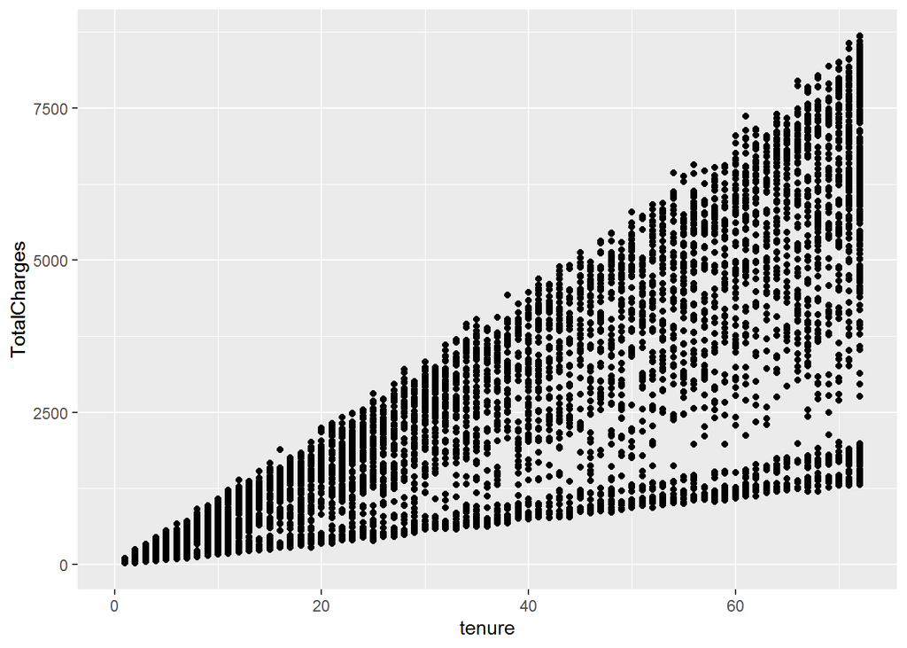

```r
ggplot(c_churn, aes(y=TotalCharges, x=tenure))+geom_point()
```

1. Assign it the color ‘wheat3’

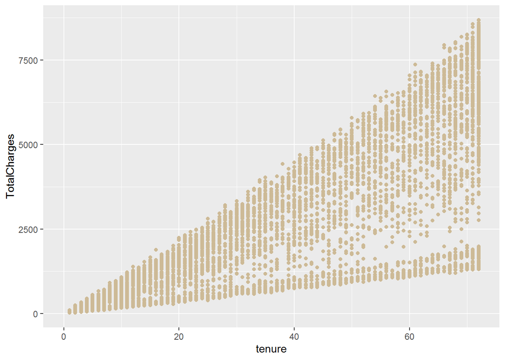

```r
ggplot(c_churn, aes(x=tenure, y=TotalCharges))+geom_point(color='wheat3')
```

2. Use ‘col’ as an aesthetic and Map ‘PaymentMethod’ to col

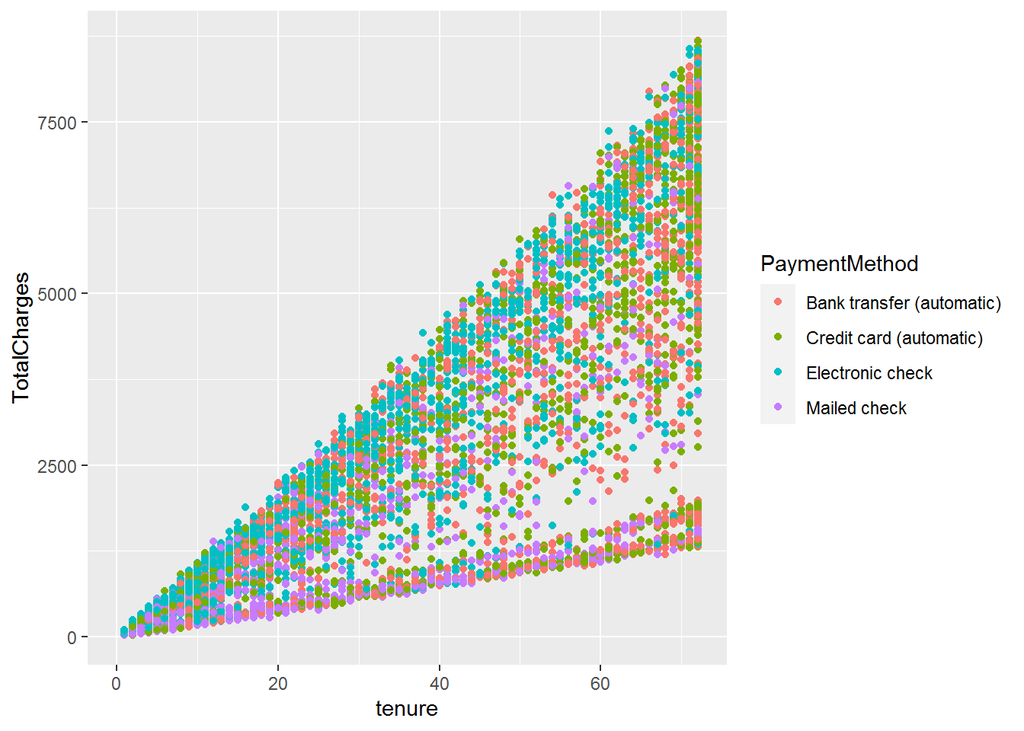

```r
ggplot(c_churn,aes(x=tenure, y=TotalCharges, col=PaymentMethod))+geom_point()
```

3. Use ‘col’ as an aesthetic and Map ‘gender’ to col

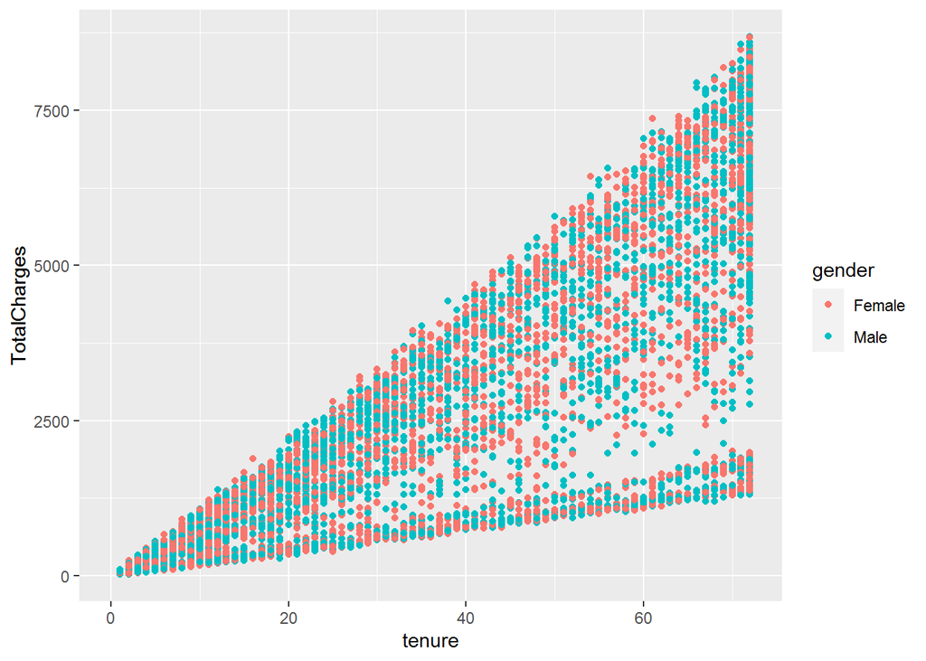

```r
ggplot(c_churn, aes(x=tenure, y= TotalCharges, col=gender))+geom_point()
```

4. Map ‘Dependents’ to both ‘col’ & ‘shape’ aesthetics

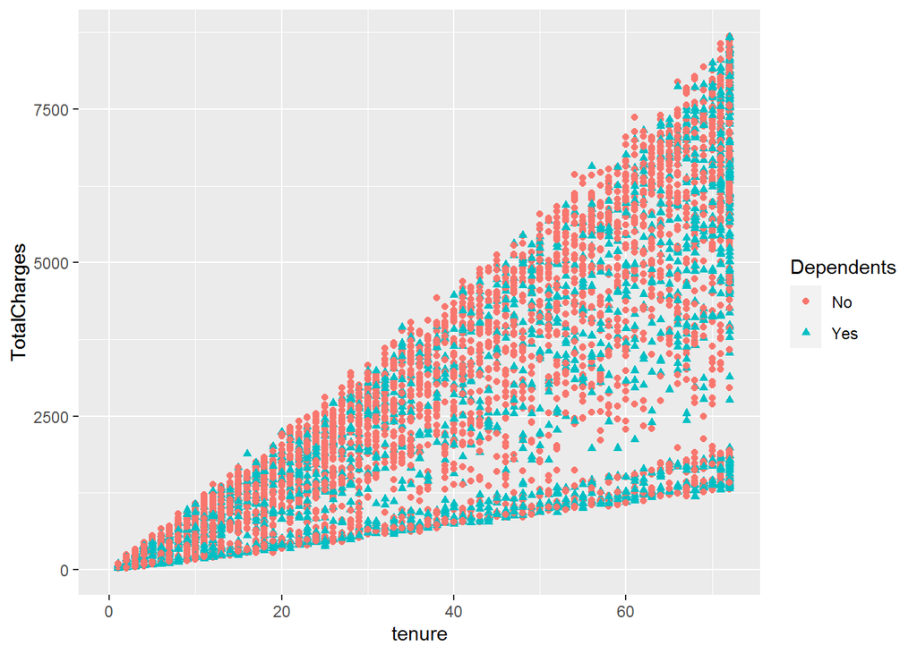

```r
ggplot(c_churn, aes(x=tenure, y=TotalCharges, col=Dependents, shape=Dependents))+geom_point()
```

2. Build a scatter-plot between ‘tenure’ & ‘MonthlyCharges’. Map ‘tenure’ to the y-axis & ‘MonthlyCharges’ to the ‘x-axis’

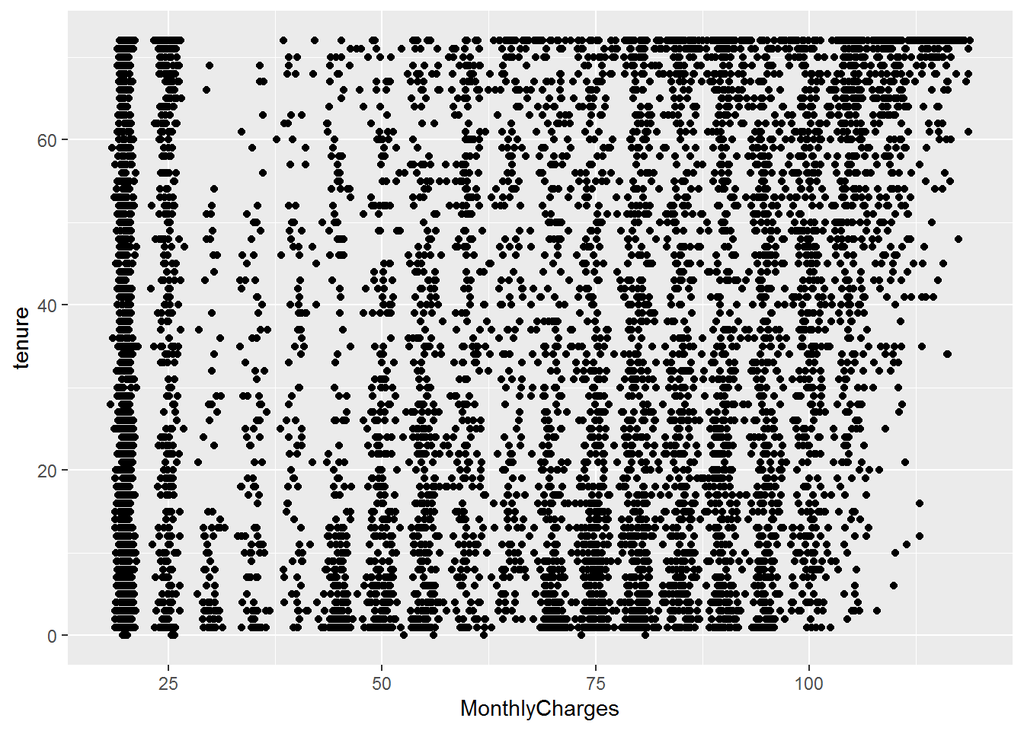

```r
ggplot(c_churn, aes(y=tenure, x= MonthlyCharges,))+geom_point()
```

a. Assign it the color ‘yellowgreen’

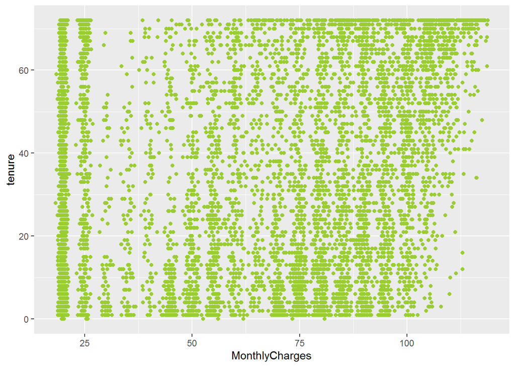

```r
ggplot(c_churn, aes(x=MonthlyCharges, y=tenure))+geom_point(col='yellowgreen')
```

2. Use ‘col’ as an aesthetic and Map ‘InternetService’ to col

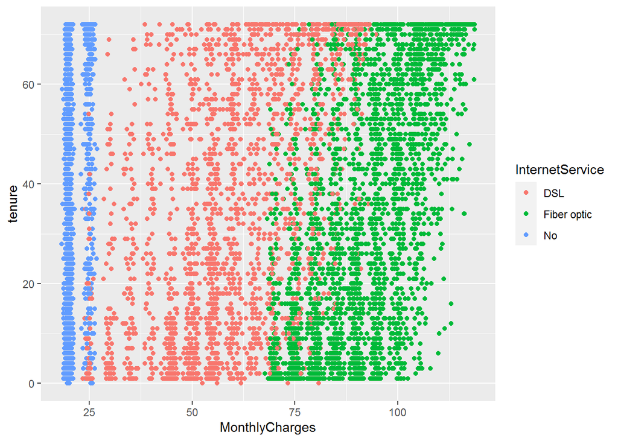

```r
ggplot(c_churn, aes(x=MonthlyCharges, y=tenure, col=InternetService))+geom_point()
```

3. Use ‘col’ as an aesthetic and Map ‘Contract’ to col

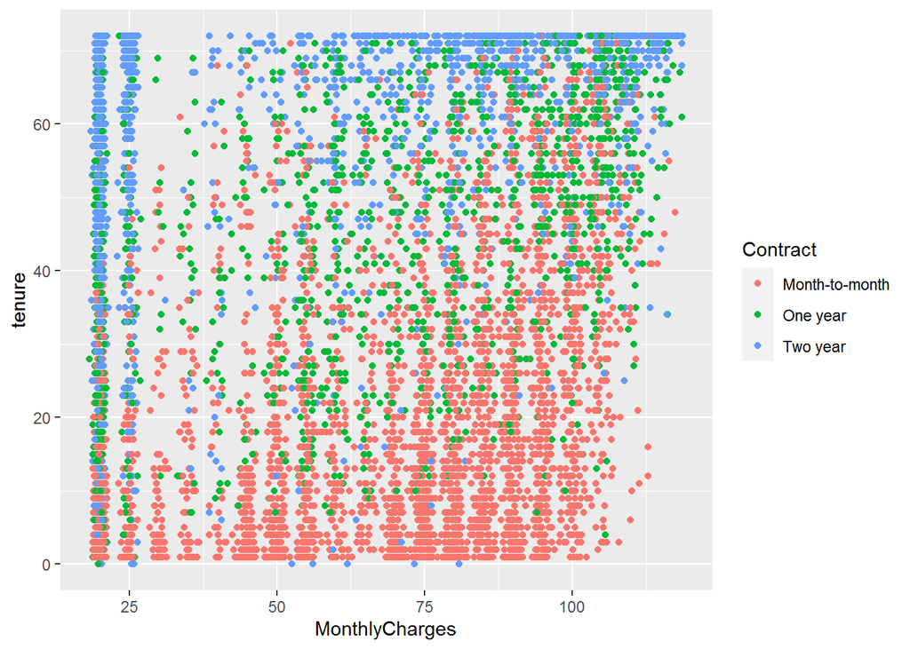

```r
ggplot(c_churn, aes(x=MonthlyCharges, y=tenure, col=Contract))+geom_point()
```

Now, Sam has to make some box-plots using the geom_boxplot() function Questions on geom_boxplot:

1. Build a box-plot between ‘tenure’ & ‘Partner’. Map ‘tenure’ to the y-axis & ‘Partner’ to the ‘x-axis’

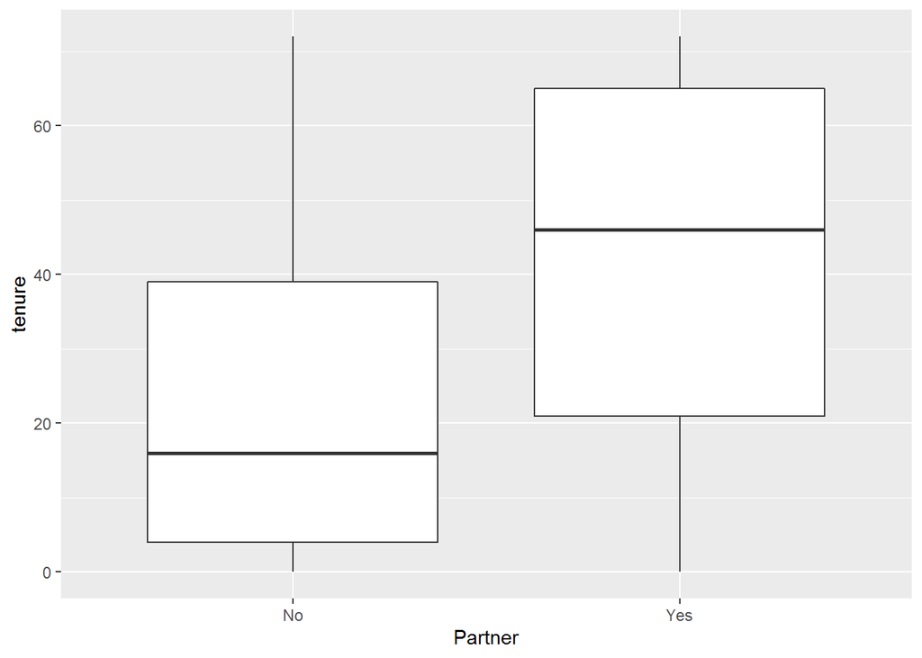

```r
ggplot(c_churn, aes(x=Partner, y=tenure))+geom_boxplot()
```

1. Assign it a fill color of ‘violet’

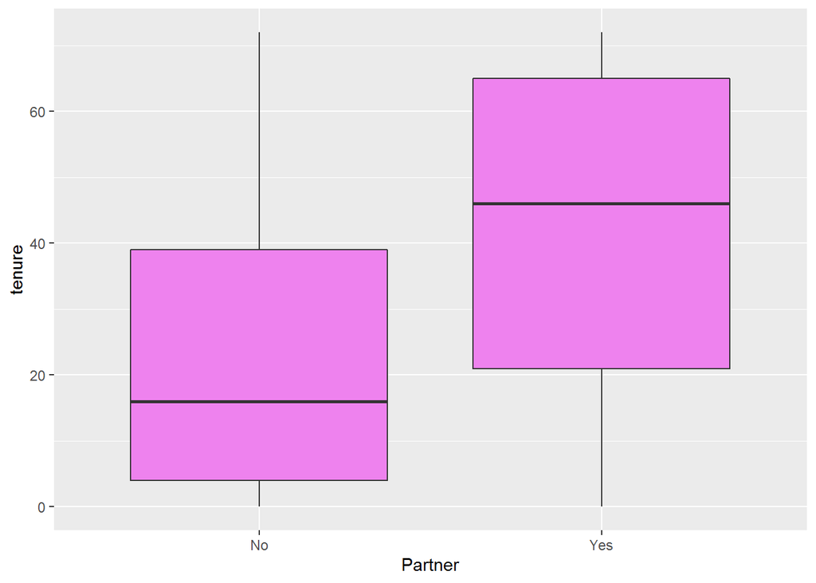

```r
ggplot(c_churn, aes(x=Partner, y=tenure))+geom_boxplot(fill='violet')
```

2. Assign it a boundary color of ‘snow3’

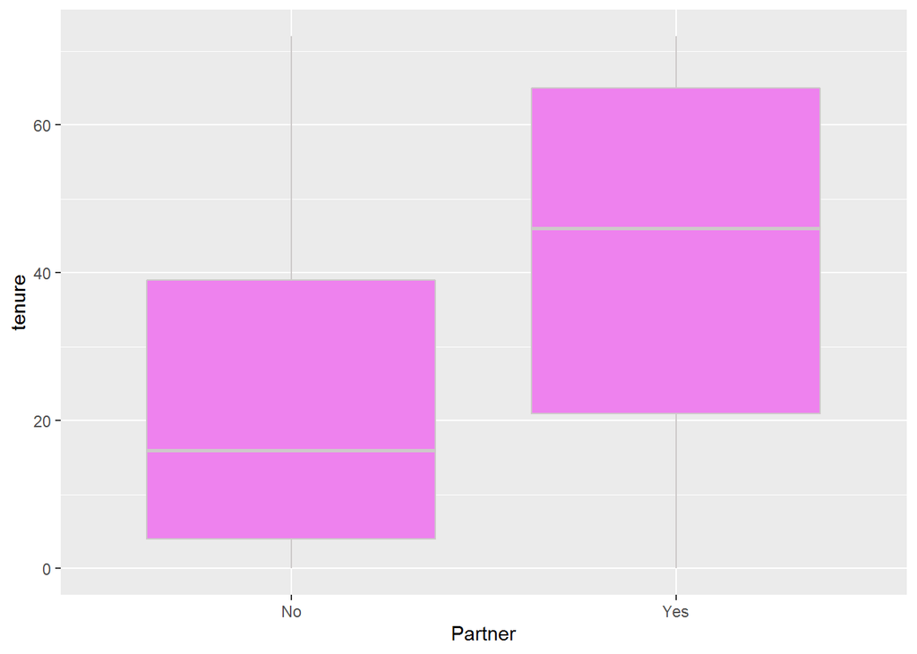

```r
ggplot(c_churn, aes(x=Partner, y=tenure))+geom_boxplot(fill='violet',col='snow3')
```

2. Build a box-plot between ‘tenure’ & ‘MultipleLines’. Map ‘tenure’ to the y-axis & ‘MultipleLines’ to the ‘x-axis’

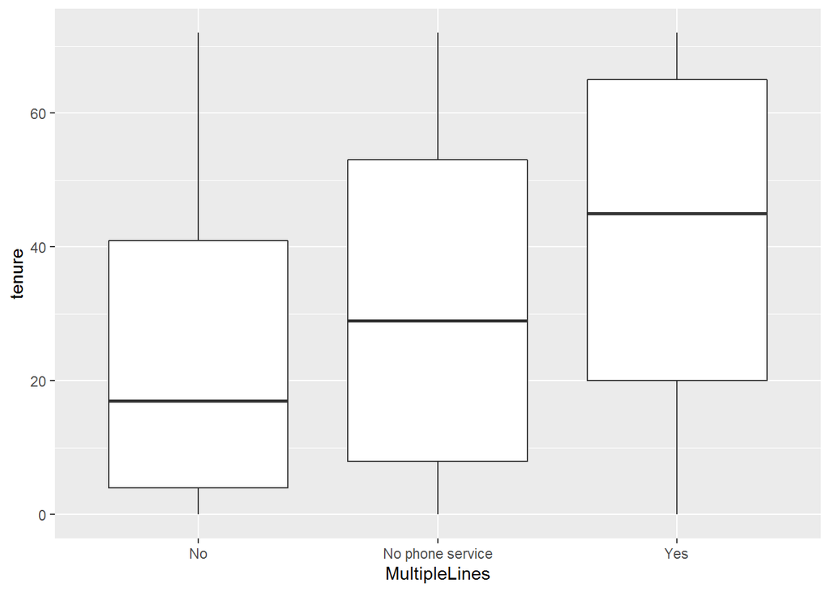

```r
ggplot(c_churn, aes(x=MultipleLines, y=tenure))+geom_boxplot()
```

1. Assign ‘Partner’ to the fill aesthetic

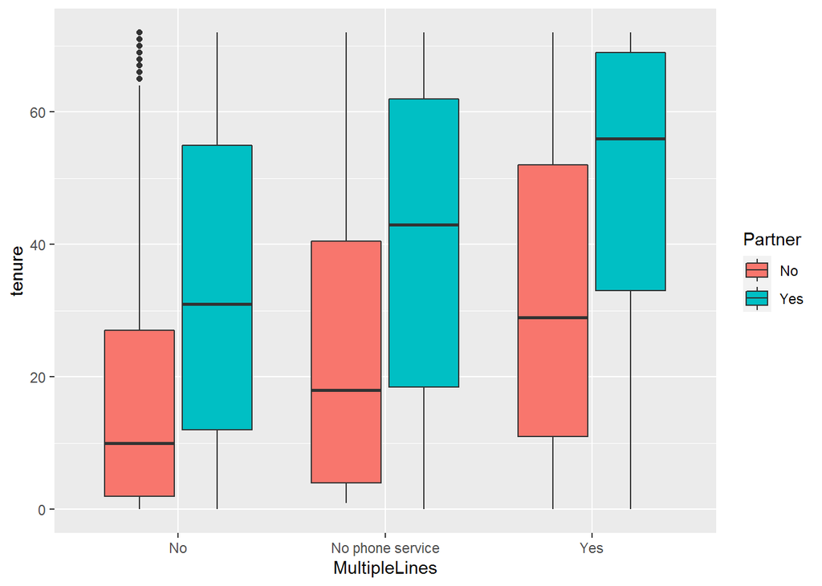

```r
ggplot(c_churn, aes(x=MultipleLines, y=tenure, fill=Partner))+geom_boxplot()
```

2. Assign ‘PhoneService’ to the fill aesthetic

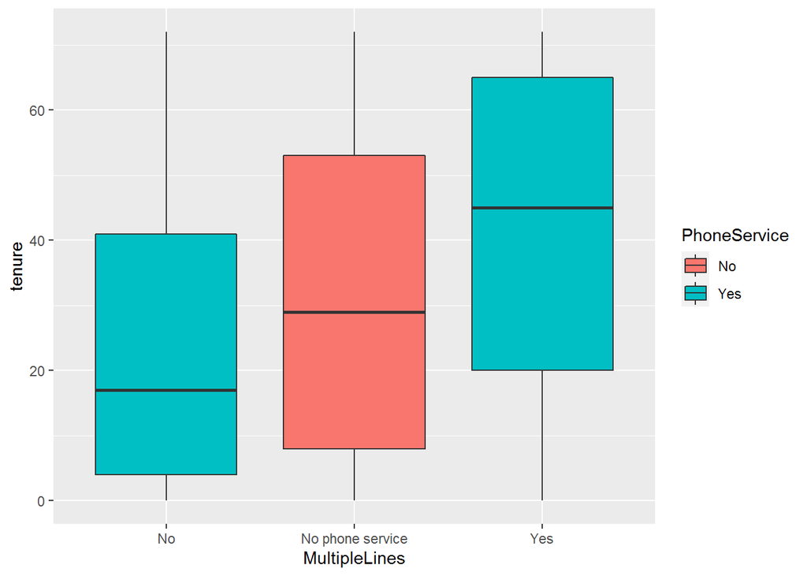

```r
ggplot(c_churn, aes(x=MultipleLines, y=tenure, fill=PhoneService))+geom_boxplot()
```

3. Build a box-plot between ‘tenure’ & ‘Contract’

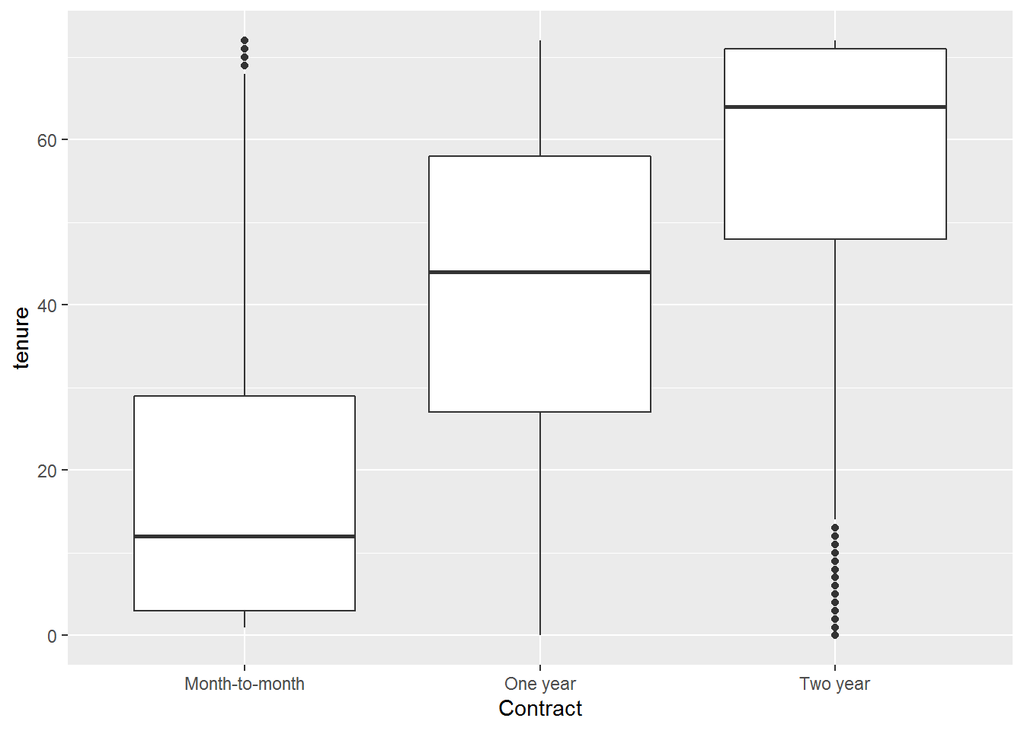

```r
ggplot(c_churn, aes(x=Contract, y=tenure))+geom_boxplot()
```

1. Assign ‘InternetService’ to the fill aesthetic

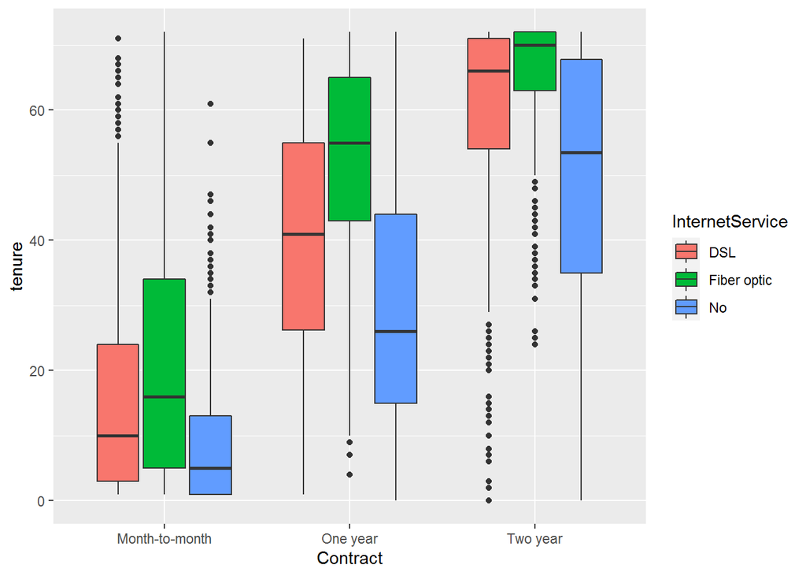

```r
ggplot(c_churn, aes(x=Contract, y=tenure, fill=InternetService))+geom_boxplot()
```

2. Assign ‘PaymentMethod’ to the fill aesthetic

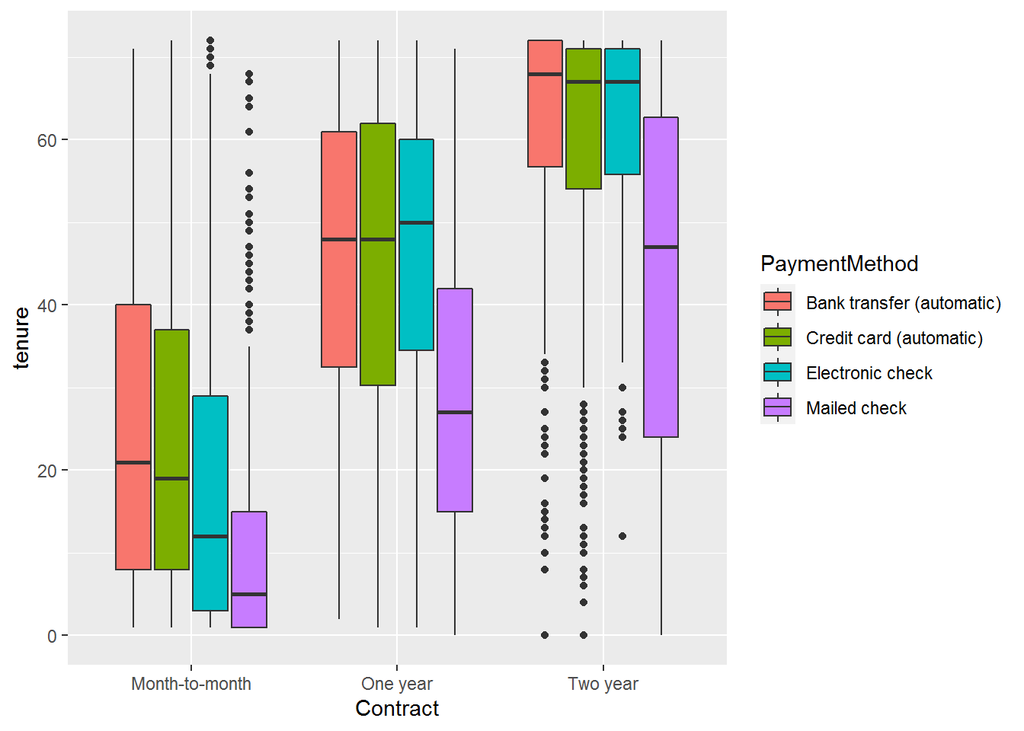

```r
ggplot(c_churn, aes(x=Contract, y=tenure, fill=PaymentMethod))+geom_boxplot()
```

Now, Sam will go ahead and facet the data Questions on facet_grid():

1. Build a box-plot between ‘tenure’ & ‘MultipleLines’. Map ‘tenure’ on the y-axis & ‘MultipleLines’ on the x-axis. Map ‘InternetService’ to the fill aesthetic

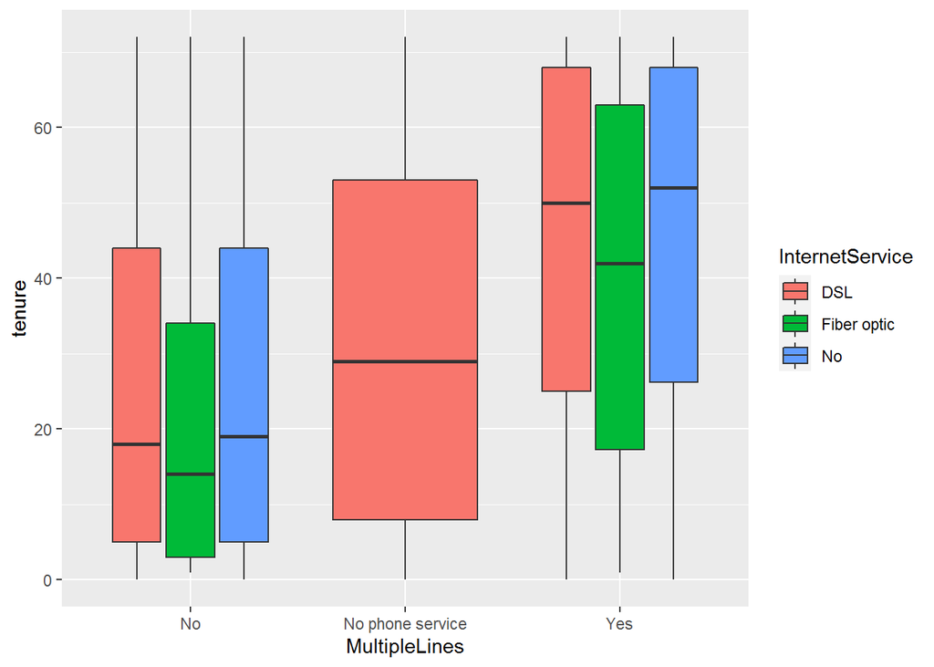

```r
ggplot(c_churn, aes(x=MultipleLines, y=tenure, fill=InternetService))+geom_boxplot()
```

1. Facet the plot w.r.t ‘InternetService’ column

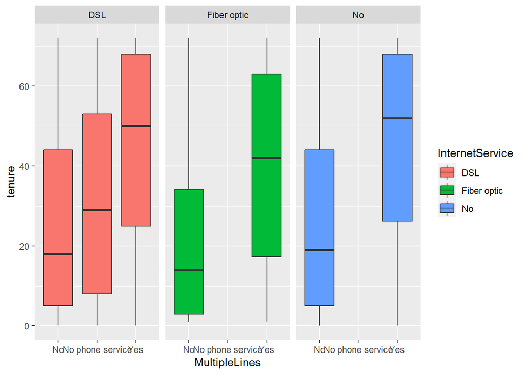

```r
ggplot(c_churn, aes(x=MultipleLines, y=tenure, fill=InternetService))+geom_boxplot()+facet_grid(~InternetService)
```

2. Build a scatter-plot between ‘TotalCharges’ & ‘tenure’. Map ‘TotalCharges’ on the y-axis & ‘tenure’ on the x-axis. Map ‘Contract’ onto col aesthetic

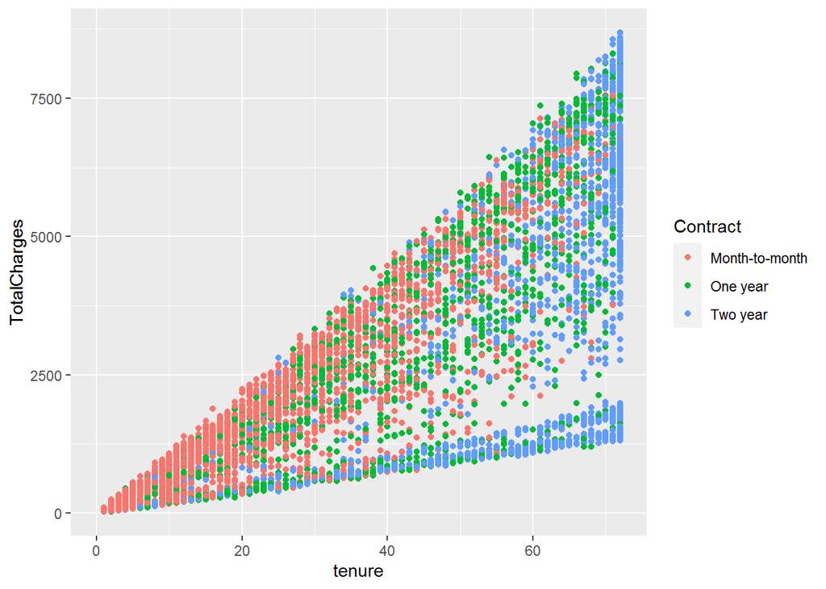

```r
ggplot(c_churn, aes(x=tenure, y=TotalCharges, col=Contract))+geom_point()
```

a. Facet the plot w.r.t ‘Contract’ column

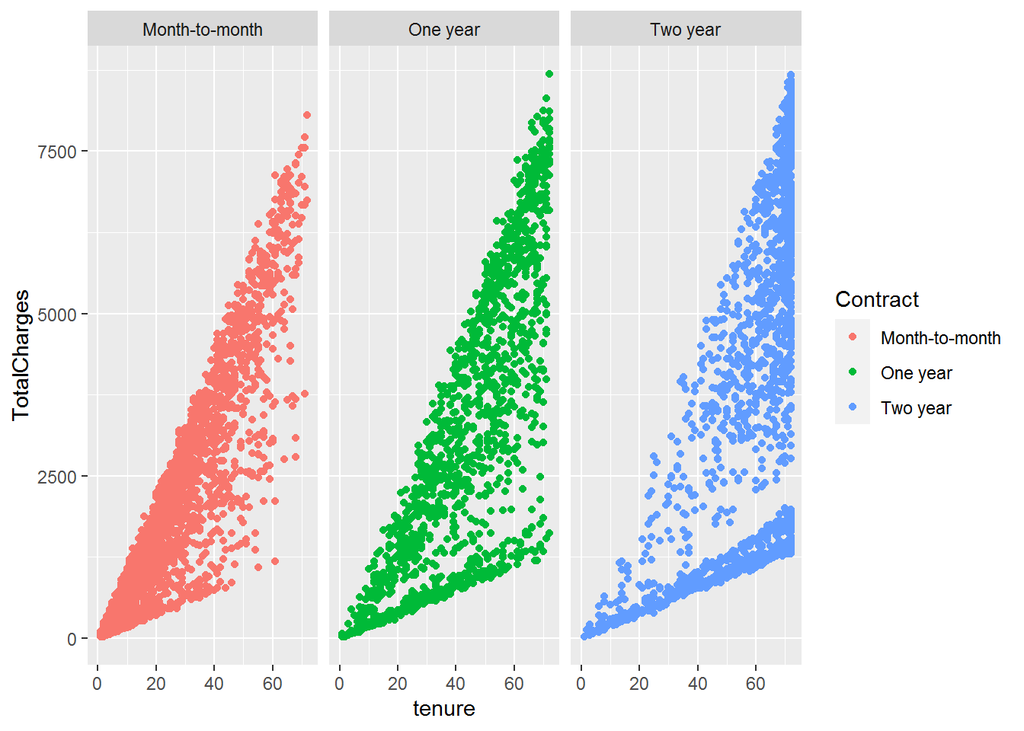

```r
ggplot(c_churn, aes(x=tenure, y=TotalCharges, col=Contract))+geom_point()+facet_grid(~Contract)
```

3. Build a histogram for the ‘MonthlyCharges’ column. Map ‘PaymentMethod’ onto fill aesthetic.

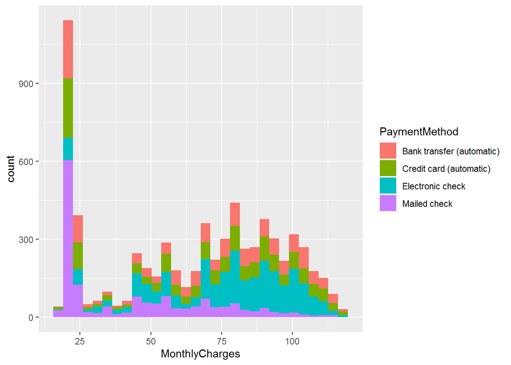

```r
ggplot(c_churn, aes(x=MonthlyCharges, fill=PaymentMethod))+geom_histogram()
```

1. Facet the plot w.r.t ‘PaymentMethod’ column

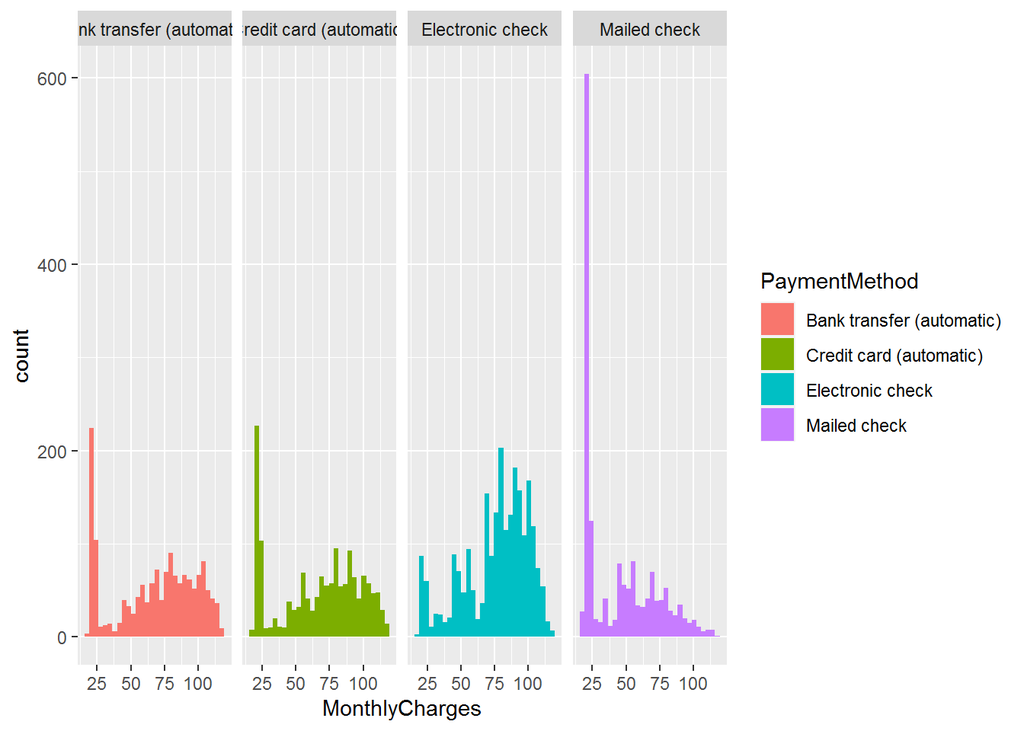

```r
ggplot(c_churn,aes(x=MonthlyCharges, fill=PaymentMethod))+geom_histogram()+facet_grid(~PaymentMethod)
```

Finally, Sam will add some themes to the plot with the theme() layer Questions on theme() layer:

1. Build a bar-plot for the ‘gender’ column. Give it a fill color of ‘blue4’

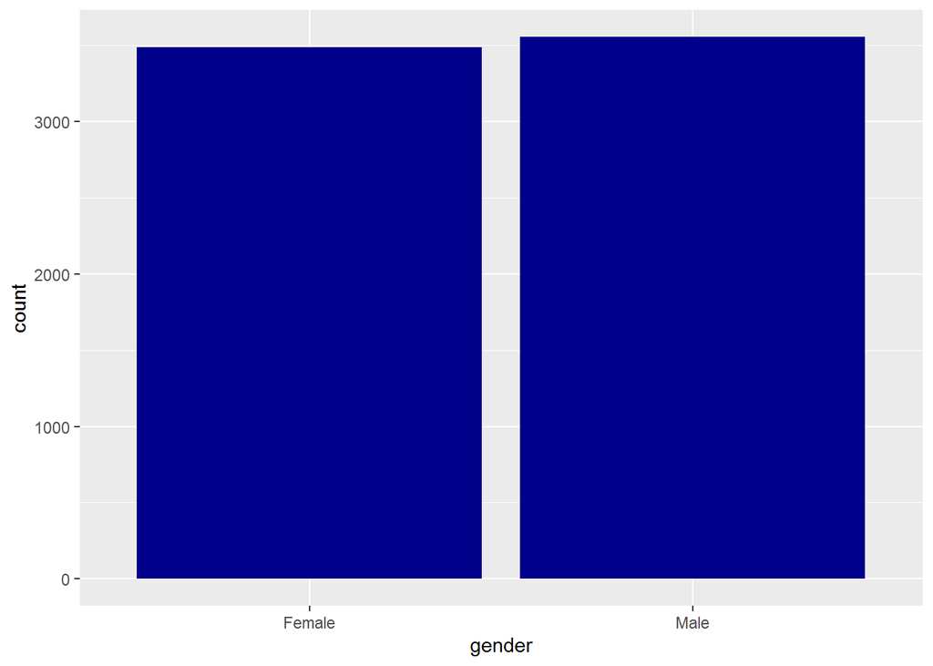

```r
ggplot(c_churn, aes(x=gender))+geom_bar(fill='blue4')
```

1. Give the panel a background color of ‘chartreuse4’

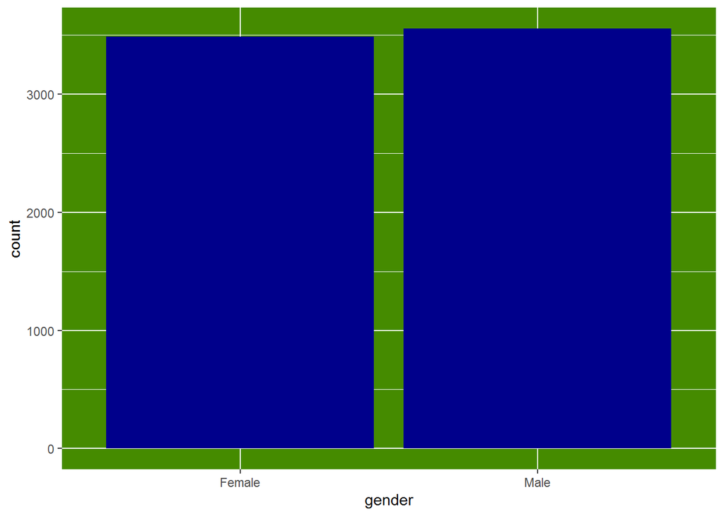

```r
ggplot(c_churn, aes(x=gender))+geom_bar(fill='blue4')+theme(panel.background=element_rect(fill='chartreuse4'))
```

2. Give the plot a background color of ‘cornsilk4’

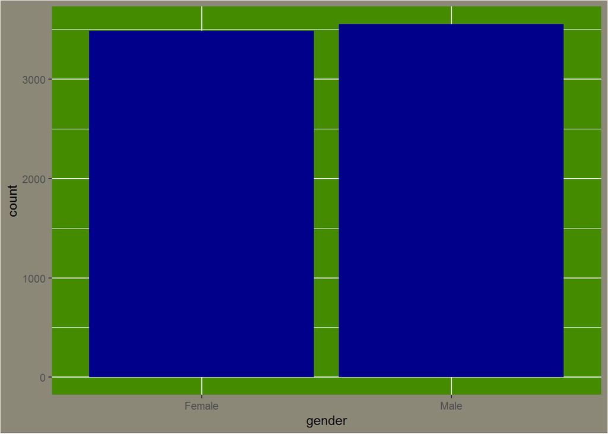

```r
ggplot(c_churn, aes(x=gender))+geom_bar(fill='blue4')+theme(panel.background = element_rect(fill = "chartreuse4"))+theme(plot.background = element_rect(fill="cornsilk4"))
```

2. Build a scatter-plot between ‘tenure’ & ‘MonthlyCharges’. Map ‘tenure’ on the y-axis & ‘MonthlyCharges’ on the x-axis. Assign a color of ‘yellowgreen’ to the points.

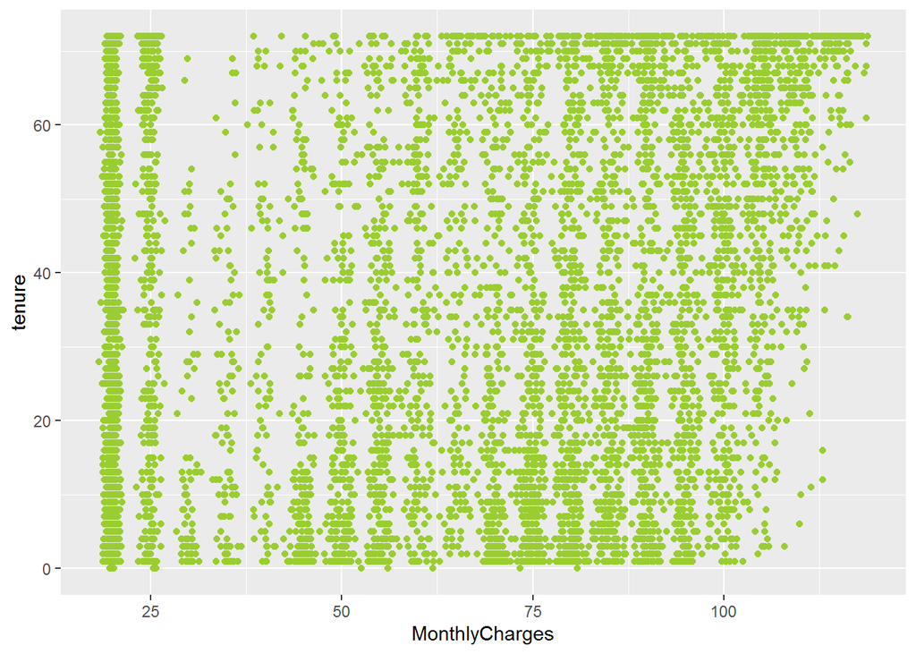

```r
ggplot(c_churn, aes(x=MonthlyCharges, y=tenure))+geom_point(col='yellowgreen')
```

1. Add a title to the plot ‘Tenure vs Monthly Charges’

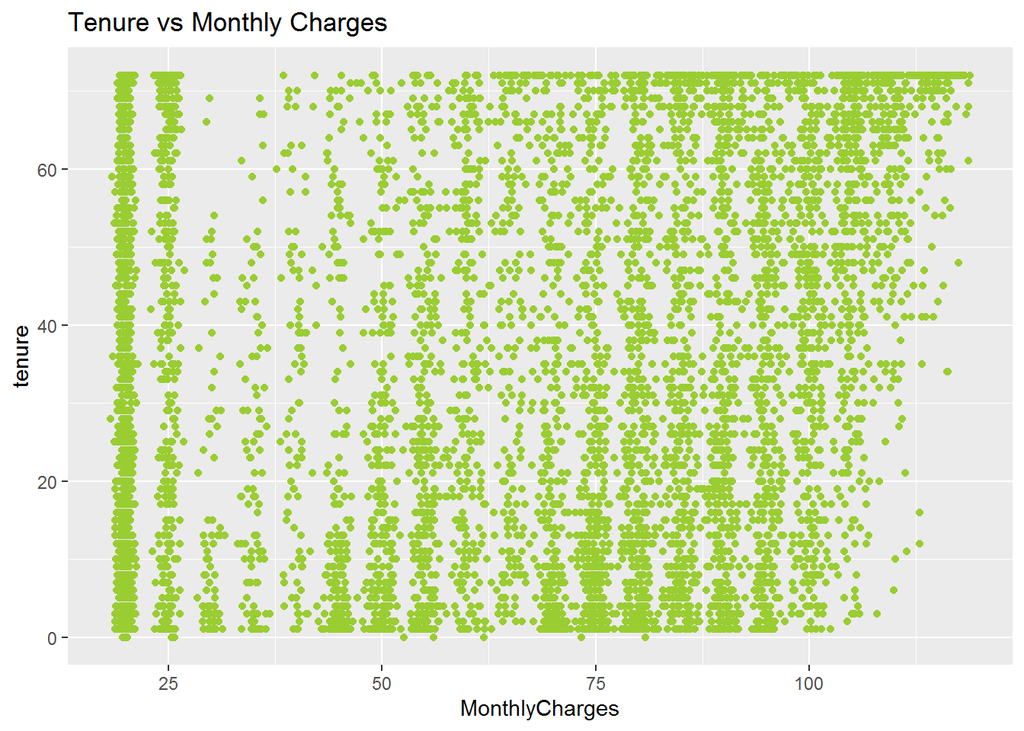

```r
ggplot(c_churn, aes(x=MonthlyCharges, y=tenure))+geom_point(col='yellowgreen')+labs(title='Tenure vs Monthly Charges')
```

b. Give the panel a background color of ‘coral2’

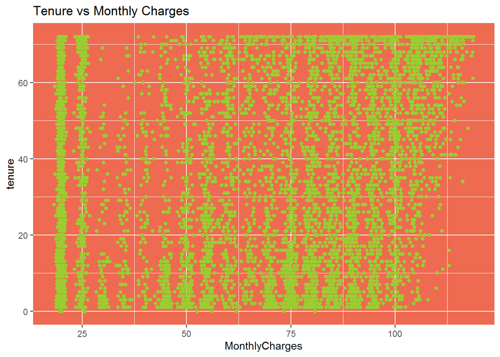

```r
ggplot(c_churn, aes(x=MonthlyCharges, y=tenure))+geom_point(col='yellowgreen')+labs(title='Tenure vs Monthly Charges')+ theme(panel.background = element_rect(fill="coral2"))
```

c. Give the plot a background color of ‘beige’

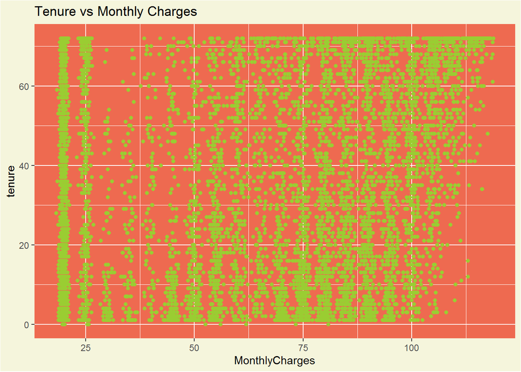

```r
ggplot(c_churn, aes(x=MonthlyCharges, y=tenure))+geom_point(col='yellowgreen')+labs(title='Tenure vs Monthly Charges')+ theme(panel.background = element_rect(fill="coral2"))+ theme(plot.background = element_rect(fill = "beige"))
```

d. Center align the title & make the color of the title to be red

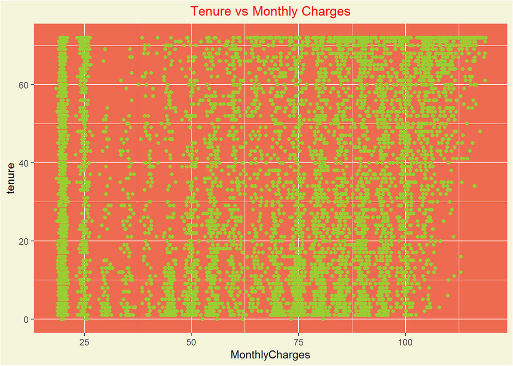

```r
ggplot(c_churn, aes(x=MonthlyCharges, y=tenure))+geom_point(col='yellowgreen')+labs(title='Tenure vs Monthly Charges')+ theme(panel.background = element_rect(fill="coral2"))+ theme(plot.background = element_rect(fill = "beige"))+theme(plot.title = element_text(hjust = 0.5,colour = "red"))
```